# Dose-response in FoodT

Matthias Aulbach

29 11 2019

# 1 Descriptive graphs and summaries

Let’s first take a look at our sample: we have 857 women and 367 men, 567 dieters at T1, 622 at T2, 94 smokers at T1, and 90 at T2. The distribution of BMI at T1 and age look as follows.

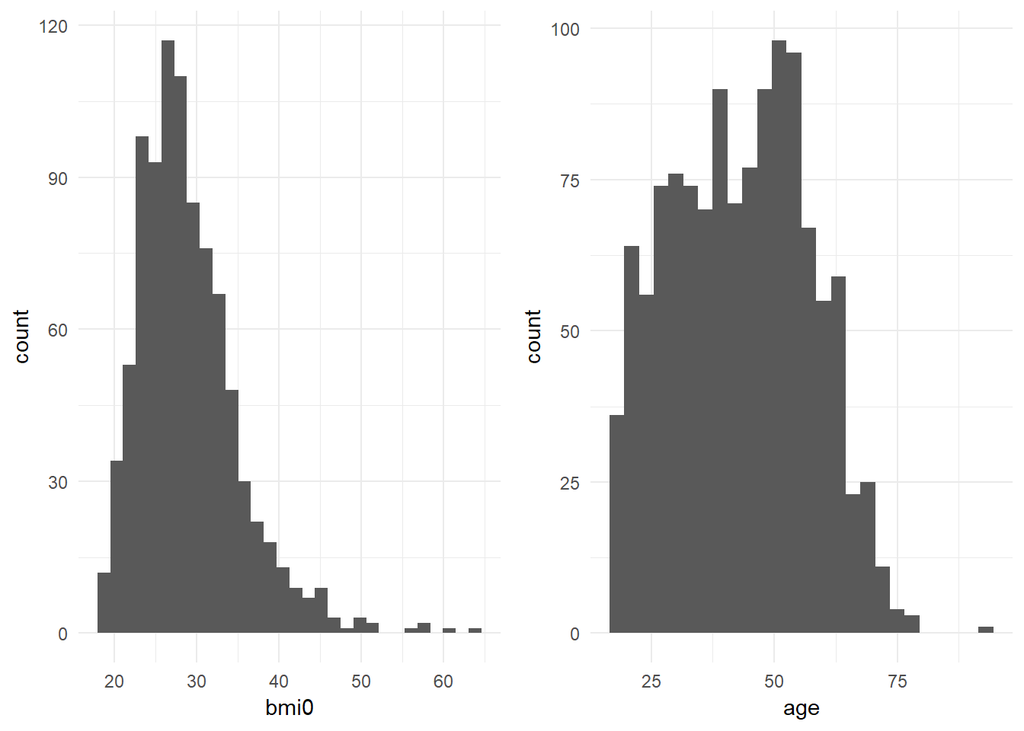

```r
bmi <- ggplot(FoodT, aes(bmi0)) +
                geom_histogram() +
  theme_minimal()
age <- ggplot(FoodT, aes(age)) +
                geom_histogram(binwidth = 3) +
  theme_minimal()
cowplot::plot_grid(bmi, age)
```

The next figure shows the distribution of training sessions over time across the sample starting with the day of the first conducted session.

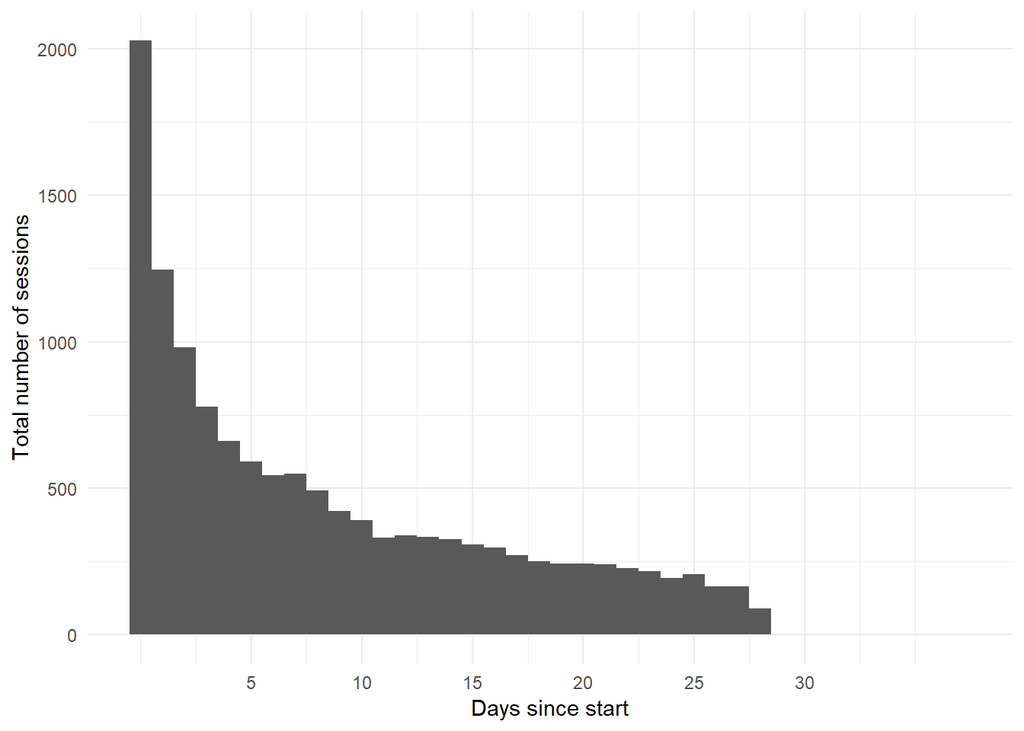

```r
# Distribution of logins over time, strating from the first use:
ggplot(FoodT_training, aes(round(days_since_start, 0))) +
  geom_histogram(binwidth = 1) +
  scale_x_continuous(breaks=c(5,10,15,20,25,30)) +
  theme_minimal() +
  xlab("Days since start") +
  ylab("Total number of sessions")
```

```r
NAs <- image_frequencies %>%
  filter(is.na(image)) %>%
  summarise_at("n", sum) %>%
  summarise_at("n", sum)
```

In total, we have 1261056 trials,

| n |
| --- |
| 18578 |

of which have missing values (which, I suppose, means that the session was not completed).

The distribution of the trials across categories is shown in the next graph with red dots being single trials, the blue triangles the mean, and the green diamonds the median.

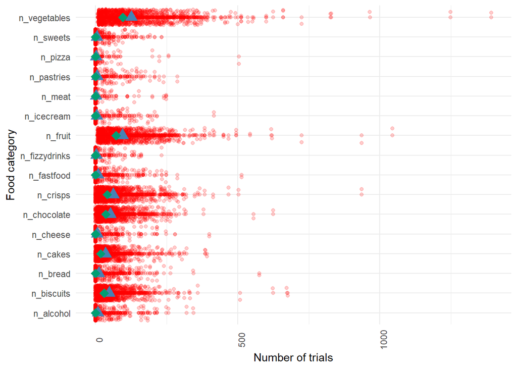

```r
ggplot(data = subset(freqs_long, category != "n_fillers" & category != "n_healthy"), aes(x = category, y = n)) +
  geom_point(color = "red", alpha = 0.2) +
  geom_jitter(color = "red", alpha = 0.2) +
  geom_point(data = subset(mean_ns, category != "n_fillers" & category != "n_healthy"), aes(x = category, y = n), size = 4, shape = 17, color = "steelblue") +
  geom_point(data = subset(median_ns, category != "n_fillers" & category != "n_healthy"), aes(x = category, y = n), size = 4, shape = 18, color = "#009E73") +
  theme_minimal() +
  theme(axis.text.x = element_text(angle = 90)) +
  ylab("Number of trials") +
  xlab("Food category") +
  coord_flip()
```

Let’s look at distributions of the total trials per person. We can see that a few people did *loads* of trials.

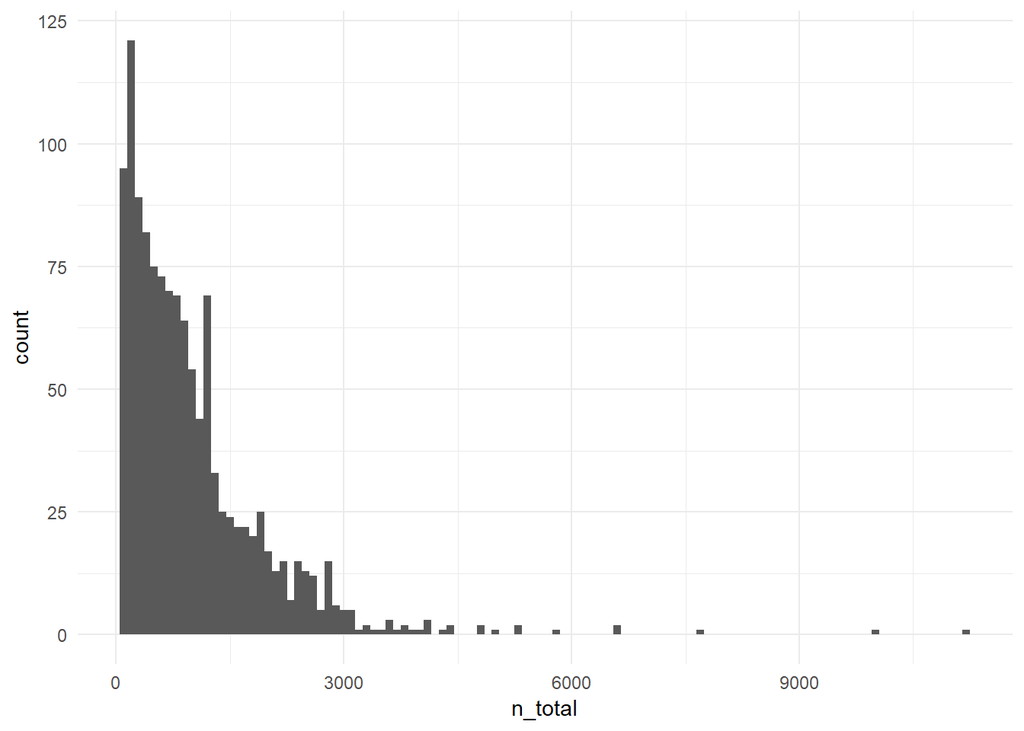

```r
# Let's look at distributions of the total trials
ggplot(FoodT, aes(n_total)) +
  geom_histogram(binwidth = 100) +
  theme_minimal()
```

Of course, we also want to see the distributions of the food intake variables. We have individuals in black and means with standard errors in red. We can nicely see that unhealthy foods tend to go down and healthy ones up. We can also see that bread, cheese, fruit, vegetables, and meat are most common, followed by sweets and chocolate.

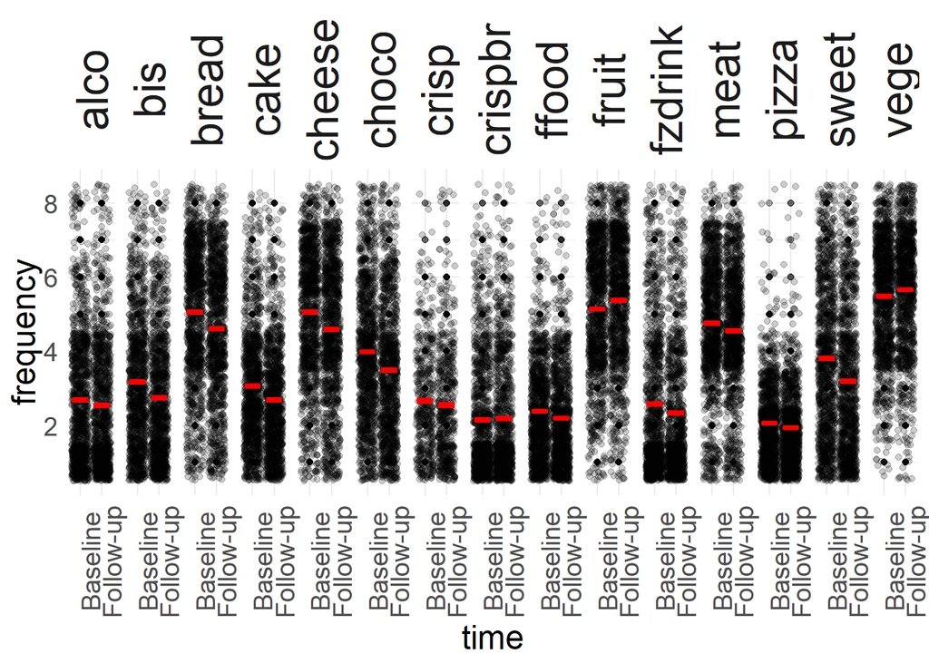

```r
ggplot(FFQ_long, aes(x =  time, y = frequency)) +
  geom_point(alpha = 0.2) +
  geom_jitter(height = 0.5, alpha = 0.2) +
  stat_summary(geom = "crossbar", fun.data = mean_se, width = 0.7, color = "red") +
  facet_grid(cols = vars(food)) +
  theme_minimal() +
  theme(text = element_text(size=18),
        axis.text.x = element_text(angle = 90),
        strip.text.x = element_text(size = 24, angle = 90))
```

Now let’s turn to the relation between reduce of food intake and the amount of trials. Here is a graph showing the overall relation. We have the linear regression line in green and a cubic function in red. In addition, we have a Loess function in blue which fits a local regression minimising residuals.

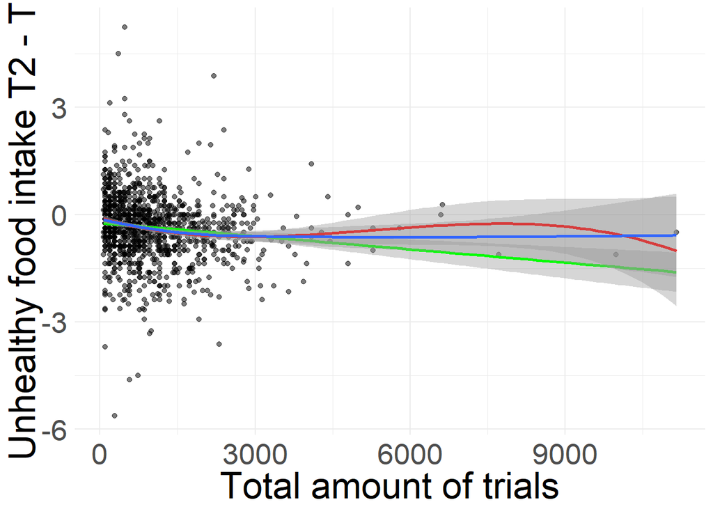

```r
FoodT <- FoodT %>% mutate(., crisp_diff = crisp1 - crisp,
                 choco_diff = choco1 - choco,
                 bis_diff = bis1 - bis,
                 sweet_diff = sweet1 - sweet,
                 cake_diff = cake1 - cake,
                 alco_diff = alco1 - alco,
                 bread_diff = bread1 - bread,
                 cheese_diff = cheese1 - cheese,
                 ffood_diff = ffood1 - ffood,
                 fzdrink_diff = fzdrink1 - fzdrink,
                 meat_diff = meat1 - meat,
                 pizza_diff = pizza1 - pizza,
                 fruit_diff = fruit1 - fruit,
                 vege_diff = vege1 - vege,
                 cripbr_diff = crispbr1 - crispbr,
                 unhlthymean_diff = unhlthymean1 - unhlthymean,
                 hlthymean_diff = hlthymean1 - hlthymean)

ggplot(FoodT, aes(x = n_total, y = unhlthymean_diff)) +
  geom_point(alpha = 0.3) +
  geom_jitter(alpha = 0.3) +
  geom_smooth(method = "lm", color = "green") +
  geom_smooth(method = "lm", formula = y~poly(x, 3), color = "red") +
  geom_smooth() +
  theme_minimal() +
  xlab("Total amount of trials") +
  ylab("Unhealthy food intake T2 - T1") +
  theme(text = element_text(size = 26))
```

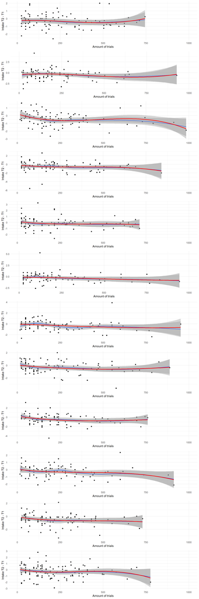

```r
ap <- ggplot(FoodT[1:100, ], aes(x = n_unhealthy, y = unhlthymean_diff)) +
  geom_point() +
  geom_jitter() +
  theme_minimal()+
  xlab("Amount of trials") +
  ylab("Intake T2 - T1") +
  geom_smooth(alpha = 0.4) +
  geom_smooth(method = "lm", formula = y~poly(x, 3), color = "red", alpha = 0.4) +
  xlim(0, 1000)
bp <- ggplot(FoodT[101:200, ], aes(x = n_unhealthy, y = unhlthymean_diff)) +
  geom_point() +
  geom_jitter() +
  theme_minimal()+
  xlab("Amount of trials") +
  ylab("Intake T2 - T1") +
  geom_smooth(alpha = 0.4) +
  geom_smooth(method = "lm", formula = y~poly(x, 3), color = "red", alpha = 0.4) +
  xlim(0, 1000)
cp <- ggplot(FoodT[201:300, ], aes(x = n_unhealthy, y = unhlthymean_diff)) +
  geom_point() +
  geom_jitter() +
  theme_minimal()+
  xlab("Amount of trials") +
  ylab("Intake T2 - T1") +
  geom_smooth(alpha = 0.4) +
  geom_smooth(method = "lm", formula = y~poly(x, 3), color = "red", alpha = 0.4) +
  xlim(0, 1000)
dp <- ggplot(FoodT[301:400, ], aes(x = n_unhealthy, y = unhlthymean_diff)) +
  geom_point() +
  geom_jitter() +
  theme_minimal()+
  xlab("Amount of trials") +
  ylab("Intake T2 - T1") +
  geom_smooth(alpha = 0.4) +
  geom_smooth(method = "lm", formula = y~poly(x, 3), color = "red", alpha = 0.4) +
  xlim(0, 1000)
ep <- ggplot(FoodT[401:500, ], aes(x = n_unhealthy, y = unhlthymean_diff)) +
  geom_point() +
  geom_jitter() +
  theme_minimal()+
  xlab("Amount of trials") +
  ylab("Intake T2 - T1") +
  geom_smooth(alpha = 0.4) +
  geom_smooth(method = "lm", formula = y~poly(x, 3), color = "red", alpha = 0.4) +
  xlim(0, 1000)
fp <- ggplot(FoodT[501:600, ], aes(x = n_unhealthy, y = unhlthymean_diff)) +
  geom_point() +
  geom_jitter() +
  theme_minimal()+
  xlab("Amount of trials") +
  ylab("Intake T2 - T1") +
  geom_smooth(alpha = 0.4) +
  geom_smooth(method = "lm", formula = y~poly(x, 3), color = "red", alpha = 0.4) +
  xlim(0, 1000)
gp <- ggplot(FoodT[601:700, ], aes(x = n_unhealthy, y = unhlthymean_diff)) +
  geom_point() +
  geom_jitter() +
  theme_minimal()+
  xlab("Amount of trials") +
  ylab("Intake T2 - T1") +
  geom_smooth(alpha = 0.4) +
  geom_smooth(method = "lm", formula = y~poly(x, 3), color = "red", alpha = 0.4) +
  xlim(0, 1000)
hp <- ggplot(FoodT[701:800, ], aes(x = n_unhealthy, y = unhlthymean_diff)) +
  geom_point() +
  geom_jitter() +
  theme_minimal()+
  xlab("Amount of trials") +
  ylab("Intake T2 - T1") +
  geom_smooth(alpha = 0.4) +
  geom_smooth(method = "lm", formula = y~poly(x, 3), color = "red", alpha = 0.4) +
  xlim(0, 1000)
ip <- ggplot(FoodT[801:900, ], aes(x = n_unhealthy, y = unhlthymean_diff)) +
  geom_point() +
  geom_jitter() +
  theme_minimal()+
  xlab("Amount of trials") +
  ylab("Intake T2 - T1") +
  geom_smooth(alpha = 0.4) +
  geom_smooth(method = "lm", formula = y~poly(x, 3), color = "red", alpha = 0.4) +
  xlim(0, 1000)
jp <- ggplot(FoodT[901:1000, ], aes(x = n_unhealthy, y = unhlthymean_diff)) +
  geom_point() +
  geom_jitter() +
  theme_minimal()+
  xlab("Amount of trials") +
  ylab("Intake T2 - T1") +
  geom_smooth(alpha = 0.4) +
  geom_smooth(method = "lm", formula = y~poly(x, 3), color = "red", alpha = 0.4) +
  xlim(0, 1000)
kp <- ggplot(FoodT[1001:1100, ], aes(x = n_unhealthy, y = unhlthymean_diff)) +
  geom_point() +
  geom_jitter() +
  theme_minimal()+
  xlab("Amount of trials") +
  ylab("Intake T2 - T1") +
  geom_smooth(alpha = 0.4) +
  geom_smooth(method = "lm", formula = y~poly(x, 3), color = "red", alpha = 0.4) +
  xlim(0, 1000)
lp <- ggplot(FoodT[1100:nrow(FoodT), ], aes(x = n_unhealthy, y = unhlthymean_diff)) +
  geom_point() +
  geom_jitter() +
  theme_minimal()+
  xlab("Amount of trials") +
  ylab("Intake T2 - T1") +
  geom_smooth(alpha = 0.4) +
  geom_smooth(method = "lm", formula = y~poly(x, 3), color = "red", alpha = 0.4) +
  xlim(0, 1000)

cowplot::plot_grid(ncol = 1,
                   ap, bp, cp, dp, ep, fp, gp, hp, ip, jp, kp, lp)
```

And then we can look at this separately for different food categories. I’m only showing some of the food categories for illustrative purposes.

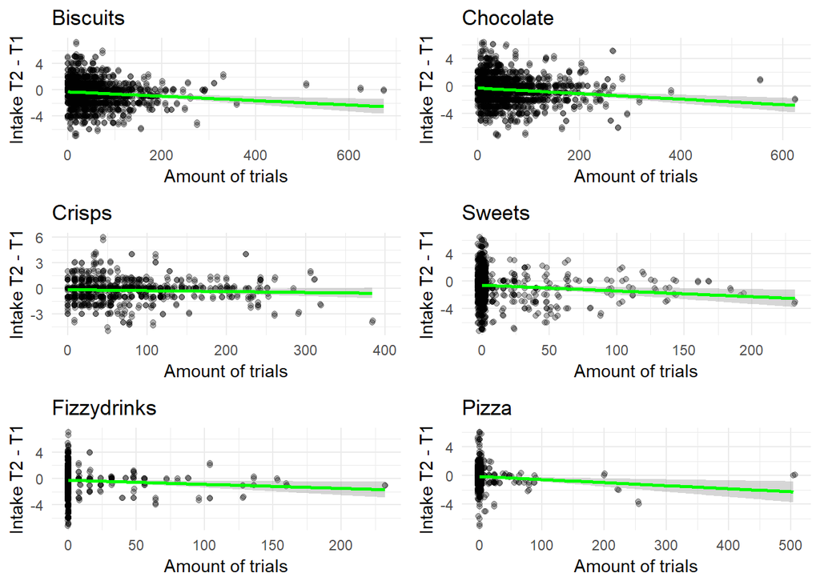

```r
# Biscuits
bis_plot <- ggplot(FoodT, aes(x = n_biscuits, y = bis_diff)) +
  geom_point(alpha = 0.3) +
  geom_jitter(alpha = 0.3) +
  geom_smooth(method = "lm", color = "green") +
  theme_minimal() +
  xlab("Amount of trials") +
  ylab("Intake T2 - T1") +

  ggtitle("Biscuits")
# Chocolate
choco_plot <- ggplot(FoodT, aes(x = n_chocolate, y = choco_diff)) +
  geom_point(alpha = 0.3) +
  geom_jitter(alpha = 0.3) +
  geom_smooth(method = "lm", color = "green") +
  theme_minimal() +
  xlab("Amount of trials") +
  ylab("Intake T2 - T1") +

  ggtitle("Chocolate")
# Crisps
crisps_plot <- ggplot(FoodT, aes(x = n_crisps, y = crisp_diff)) +
  geom_point(alpha = 0.3) +
  geom_jitter(alpha = 0.3) +
  geom_smooth(method = "lm", color = "green") +
  theme_minimal() +
  xlab("Amount of trials") +
  ylab("Intake T2 - T1") +

  xlim(0, 400)  +
  ggtitle("Crisps")
# Sweets
sweets_plot <- ggplot(FoodT, aes(x = n_sweets, y = sweet_diff)) +
  geom_point(alpha = 0.3) +
  geom_jitter(alpha = 0.3) +
  geom_smooth(method = "lm", color = "green") +
  theme_minimal() +
  xlab("Amount of trials") +
  ylab("Intake T2 - T1") +

  ggtitle("Sweets")
# Fizzydrinks
fizzydrinks_plot <- ggplot(FoodT, aes(x = n_fizzydrinks, y = fzdrink_diff)) +
  geom_point(alpha = 0.3) +
  geom_jitter(alpha = 0.3) +
  geom_smooth(method = "lm", color = "green") +
  theme_minimal() +
  xlab("Amount of trials") +
  ylab("Intake T2 - T1") +

  ggtitle("Fizzydrinks")
# Pizza
pizza_plot <- ggplot(FoodT, aes(x = n_pizza, y = pizza_diff)) +
  geom_point(alpha = 0.3) +
  geom_jitter(alpha = 0.3) +
  geom_smooth(method = "lm", color = "green") +
  theme_minimal() +
  xlab("Amount of trials") +
  ylab("Intake T2 - T1") +

  ggtitle("Pizza")


cowplot::plot_grid(nrow = 3, ncol =2,
         bis_plot,
         choco_plot,
         crisps_plot,
         sweets_plot,
         fizzydrinks_plot,
         pizza_plot)
```

# 2 Hypothesis 1: unhealthy foods

## 2.1 Overall unhealthy foods

Let’s dive into the regression models. First off, we run a random-intercept mixed model with unhealthy food intake as outcome and the time X amount of trials with unhealthy foods as the main predictor of interest. We then add gender, BMI, smoking and dieting status, and age as control variables. In addition, I am also running the quadratic and cubic terms in the model since a linear relationship might not describe the data so well.

```r
FoodT_long <- FoodT %>%
  dplyr::select(., email_id, metcon0, bmi0, age, gender, smoker0, diet0, n_unhealthy, unhlthymean, unhlthymean1) %>%
  gather(., "timepoint", "unhealthy_intake", c("unhlthymean", "unhlthymean1")) %>%
  dplyr::mutate(timepoint = recode_factor(timepoint,
                                   "unhlthymean" = "T1",
                                   "unhlthymean1" = "T2"),
                 n_unhealthy_sq = n_unhealthy^2,
                n_unhealthy_cub = n_unhealthy^3)

mixed_model_FFQ_T2_no_cov <- lme4::lmer(unhealthy_intake ~ n_unhealthy*timepoint +
                                   (1|email_id),
                                 data = FoodT_long,
                                 na.action = na.exclude)

mixed_model_FFQ_T2_no_cov_quad <- lme4::lmer(unhealthy_intake ~ poly(n_unhealthy, 2)*timepoint +
                                   (1|email_id),
                                data = FoodT_long,
                                na.action = na.exclude)

mixed_model_FFQ_T2_no_cov_cub <- lme4::lmer(unhealthy_intake ~ poly(n_unhealthy, 3)*timepoint +
                                   (1|email_id),
                                data = FoodT_long,
                                na.action = na.exclude)

mixed_model_FFQ_T2 <- lme4::lmer(unhealthy_intake ~ n_unhealthy*timepoint +
                                   bmi0 + age + as.factor(gender) + as.factor(smoker0) + as.factor(diet0) + factor(metcon0) +
                                   (1|email_id),
                                 data = FoodT_long,
                                 na.action = na.exclude)

mixed_model_FFQ_T2_quad <- lme4::lmer(unhealthy_intake ~ poly(n_unhealthy, 2)*timepoint +
                                   bmi0 + age + as.factor(gender) + as.factor(smoker0) + as.factor(diet0) + factor(metcon0) +
                                   (1|email_id),
                                 data = FoodT_long,
                                 na.action = na.exclude)

mixed_model_FFQ_T2_cub <- lme4::lmer(unhealthy_intake ~ poly(n_unhealthy, 3)*timepoint +
                                   bmi0 + age + as.factor(gender) + as.factor(smoker0) + as.factor(diet0) + factor(metcon0) +
                                   (1|email_id),
                                 data = FoodT_long,
                                 na.action = na.exclude)


stargazer::stargazer(mixed_model_FFQ_T2_no_cov, mixed_model_FFQ_T2_no_cov_quad, mixed_model_FFQ_T2_no_cov_cub,
                     mixed_model_FFQ_T2, mixed_model_FFQ_T2_quad, mixed_model_FFQ_T2_cub,
                     type = "html", digits = 5)
```

|  | *Dependent variable:* |  |  |  |  |  |
| --- | --- | --- | --- | --- | --- | --- |
|  | unhealthy_intake |  |  |  |  |  |
|  | (1) | (2) | (3) | (4) | (5) | (6) |
| n_unhealthy | -0.00015 |  |  | -0.00012 |  |  |
|  | (0.00012) |  |  | (0.00014) |  |  |
| poly(n_unhealthy, 2)1 |  | -1.85321 |  |  | -1.18755 |  |
|  |  | (1.42004) |  |  | (1.67150) |  |
| poly(n_unhealthy, 2)2 |  | -1.39986 |  |  | -2.20707 |  |
|  |  | (1.42000) |  |  | (1.52378) |  |
| poly(n_unhealthy, 3)1 |  |  | -1.85194 |  |  | -1.31777 |
|  |  |  | (1.41982) |  |  | (1.67429) |
| poly(n_unhealthy, 3)2 |  |  | -1.40125 |  |  | -2.38289 |
|  |  |  | (1.41978) |  |  | (1.53394) |
| poly(n_unhealthy, 3)3 |  |  | 0.79164 |  |  | 1.74273 |
|  |  |  | (1.41995) |  |  | (1.56444) |
| timepointT2 | -0.23236*** | -0.35567*** | -0.35580*** | -0.22616*** | -0.35484*** | -0.35352*** |
|  | (0.03884) | (0.02701) | (0.02697) | (0.04387) | (0.03071) | (0.03064) |
| bmi0 |  |  |  | 0.01908*** | 0.01907*** | 0.01907*** |
|  |  |  |  | (0.00489) | (0.00489) | (0.00489) |
| age |  |  |  | -0.01147*** | -0.01155*** | -0.01157*** |
|  |  |  |  | (0.00224) | (0.00228) | (0.00229) |
| as.factor(gender)Male |  |  |  | 0.04828 | 0.04793 | 0.04722 |
|  |  |  |  | (0.06481) | (0.06499) | (0.06503) |
| as.factor(smoker0)Yes |  |  |  | 0.04610 | 0.04611 | 0.04634 |
|  |  |  |  | (0.11112) | (0.11119) | (0.11127) |
| as.factor(diet0)Yes |  |  |  | -0.19046*** | -0.19044*** | -0.18990*** |
|  |  |  |  | (0.05850) | (0.05855) | (0.05870) |
| factor(metcon0)Yes |  |  |  | 0.07809 | 0.07794 | 0.07814 |
|  |  |  |  | (0.09014) | (0.09032) | (0.09038) |
| n_unhealthy:timepointT2 | -0.00049*** |  |  | -0.00051*** |  |  |
|  | (0.00011) |  |  | (0.00013) |  |  |
| poly(n_unhealthy, 2)1:timepointT2 |  | -5.97473*** |  |  | -6.61549*** |  |
|  |  | (1.33411) |  |  | (1.51865) |  |
| poly(n_unhealthy, 2)2:timepointT2 |  | 3.58029*** |  |  | 3.94459*** |  |
|  |  | (1.33044) |  |  | (1.39511) |  |
| poly(n_unhealthy, 3)1:timepointT2 |  |  | -5.99592*** |  |  | -6.39501*** |
|  |  |  | (1.33199) |  |  | (1.51841) |
| poly(n_unhealthy, 3)2:timepointT2 |  |  | 3.60522*** |  |  | 4.29180*** |
|  |  |  | (1.32835) |  |  | (1.40060) |
| poly(n_unhealthy, 3)3:timepointT2 |  |  | -2.96303** |  |  | -3.23238** |
|  |  |  | (1.32840) |  |  | (1.44714) |
| Constant | 3.29885*** | 3.26031*** | 3.26031*** | 3.28228*** | 3.25722*** | 3.25718*** |
|  | (0.04110) | (0.02859) | (0.02859) | (0.15459) | (0.15645) | (0.15654) |
| Observations | 2,468 | 2,468 | 2,468 | 2,468 | 2,468 | 2,468 |
| Log Likelihood | -3,244.92000 | -3,220.10600 | -3,215.12500 | -2,338.77000 | -2,313.48600 | -2,308.45300 |
| Akaike Inf. Crit. | 6,501.84100 | 6,456.21200 | 6,450.25100 | 4,701.53900 | 4,654.97200 | 4,648.90700 |
| Bayesian Inf. Crit. | 6,536.60500 | 6,502.56400 | 6,508.19100 | 4,767.27700 | 4,731.66600 | 4,736.55800 |
| *Note:* | p<0.1; p<0.05; p<0.01 |  |  |  |  |  |

Adding the covariates does not change the results too much. The regression weight for the time X training interaction in the full model is -0.0005065 (as opposed to the one without the covariates -0.0004894). So one single trial reduces the average unhealthy FFQ score by -0.0005065.

I then run the model again, excluding all obese participants. This actually seems to have some influence on the effects: the quadratic and cubic effects are no longer significant at .05 level, and I don’t think that’s due to a reduced sample size: We still have 581 people in the sample.

```r
mixed_model_FFQ_T2_no_cov <- lme4::lmer(unhealthy_intake ~ n_unhealthy*timepoint +
                                          (1|email_id),
                                        data = subset(FoodT_long, bmi0 < 30),
                                        na.action = na.exclude)

mixed_model_FFQ_T2_no_cov_quad <- lme4::lmer(unhealthy_intake ~ poly(n_unhealthy, 2)*timepoint +
                                               (1|email_id),
                                             data = subset(FoodT_long, bmi0 < 30),
                                             na.action = na.exclude)

mixed_model_FFQ_T2_no_cov_cub <- lme4::lmer(unhealthy_intake ~ poly(n_unhealthy, 3)*timepoint +
                                              (1|email_id),
                                            data = subset(FoodT_long, bmi0 < 30),
                                            na.action = na.exclude)

mixed_model_FFQ_T2 <- lme4::lmer(unhealthy_intake ~ n_unhealthy*timepoint +
                                   bmi0 + age + as.factor(gender) + as.factor(smoker0) + as.factor(diet0) + factor(metcon0) +
                                   (1|email_id),
                                 data = subset(FoodT_long, bmi0 < 30),
                                 na.action = na.exclude)

mixed_model_FFQ_T2_quad <- lme4::lmer(unhealthy_intake ~ poly(n_unhealthy, 2)*timepoint +
                                        bmi0 + age + as.factor(gender) + as.factor(smoker0) + as.factor(diet0) + factor(metcon0) +
                                        (1|email_id),
                                      data = subset(FoodT_long, bmi0 < 30),
                                      na.action = na.exclude)

mixed_model_FFQ_T2_cub <- lme4::lmer(unhealthy_intake ~ poly(n_unhealthy, 3)*timepoint +
                                       bmi0 + age + as.factor(gender) + as.factor(smoker0) + as.factor(diet0) + factor(metcon0) +
                                       (1|email_id),
                                     data = subset(FoodT_long, bmi0 < 30),
                                     na.action = na.exclude)

stargazer::stargazer(mixed_model_FFQ_T2_no_cov, mixed_model_FFQ_T2_no_cov_quad, mixed_model_FFQ_T2_no_cov_cub,
                     mixed_model_FFQ_T2, mixed_model_FFQ_T2_quad, mixed_model_FFQ_T2_cub,
                     type = "html", digits = 5)
```

|  | *Dependent variable:* |  |  |  |  |  |
| --- | --- | --- | --- | --- | --- | --- |
|  | unhealthy_intake |  |  |  |  |  |
|  | (1) | (2) | (3) | (4) | (5) | (6) |
| n_unhealthy | -0.00038** |  |  | -0.00025 |  |  |
|  | (0.00018) |  |  | (0.00018) |  |  |
| poly(n_unhealthy, 2)1 |  | -2.97194** |  |  | -1.94641 |  |
|  |  | (1.36543) |  |  | (1.39779) |  |
| poly(n_unhealthy, 2)2 |  | -0.59838 |  |  | -1.50508 |  |
|  |  | (1.36543) |  |  | (1.38202) |  |
| poly(n_unhealthy, 3)1 |  |  | -2.97194** |  |  | -1.94401 |
|  |  |  | (1.36651) |  |  | (1.39893) |
| poly(n_unhealthy, 3)2 |  |  | -0.59838 |  |  | -1.51238 |
|  |  |  | (1.36651) |  |  | (1.38330) |
| poly(n_unhealthy, 3)3 |  |  | 0.52725 |  |  | 0.85306 |
|  |  |  | (1.36651) |  |  | (1.36126) |
| timepointT2 | -0.19188*** | -0.29893*** | -0.29900*** | -0.18953*** | -0.28990*** | -0.29001*** |
|  | (0.05305) | (0.03704) | (0.03705) | (0.05319) | (0.03722) | (0.03722) |
| bmi0 |  |  |  | 0.03313** | 0.03322** | 0.03329** |
|  |  |  |  | (0.01367) | (0.01369) | (0.01371) |
| age |  |  |  | -0.01241*** | -0.01260*** | -0.01266*** |
|  |  |  |  | (0.00274) | (0.00280) | (0.00281) |
| as.factor(gender)Male |  |  |  | -0.02035 | -0.02006 | -0.02035 |
|  |  |  |  | (0.08274) | (0.08286) | (0.08293) |
| as.factor(smoker0)Yes |  |  |  | -0.02331 | -0.02208 | -0.02121 |
|  |  |  |  | (0.13576) | (0.13591) | (0.13605) |
| as.factor(diet0)Yes |  |  |  | -0.13544* | -0.13539* | -0.13495* |
|  |  |  |  | (0.07260) | (0.07267) | (0.07275) |
| factor(metcon0)Yes |  |  |  | 0.10252 | 0.09859 | 0.09672 |
|  |  |  |  | (0.12381) | (0.12451) | (0.12484) |
| n_unhealthy:timepointT2 | -0.00046*** |  |  | -0.00043*** |  |  |
|  | (0.00016) |  |  | (0.00016) |  |  |
| poly(n_unhealthy, 2)1:timepointT2 |  | -3.59084*** |  |  | -3.36960*** |  |
|  |  | (1.25234) |  |  | (1.25695) |  |
| poly(n_unhealthy, 2)2:timepointT2 |  | 2.34489* |  |  | 2.21701* |  |
|  |  | (1.24961) |  |  | (1.24893) |  |
| poly(n_unhealthy, 3)1:timepointT2 |  |  | -3.59791*** |  |  | -3.37055*** |
|  |  |  | (1.25276) |  |  | (1.25722) |
| poly(n_unhealthy, 3)2:timepointT2 |  |  | 2.35287* |  |  | 2.22375* |
|  |  |  | (1.25005) |  |  | (1.24923) |
| poly(n_unhealthy, 3)3:timepointT2 |  |  | -0.98335 |  |  | -1.08304 |
|  |  |  | (1.25083) |  |  | (1.25239) |
| Constant | 3.28217*** | 3.19281*** | 3.19281*** | 2.97110*** | 2.91752*** | 2.91814*** |
|  | (0.05735) | (0.04006) | (0.04009) | (0.33446) | (0.33483) | (0.33512) |
| Observations | 1,162 | 1,162 | 1,162 | 1,162 | 1,162 | 1,162 |
| Log Likelihood | -1,479.62300 | -1,457.57800 | -1,455.01000 | -1,458.55000 | -1,436.72800 | -1,434.06500 |
| Akaike Inf. Crit. | 2,971.24600 | 2,931.15600 | 2,930.02000 | 2,941.10100 | 2,901.45500 | 2,900.13000 |
| Bayesian Inf. Crit. | 3,001.47900 | 2,971.46700 | 2,980.40700 | 3,001.38600 | 2,971.78800 | 2,980.51000 |
| *Note:* | p<0.1; p<0.05; p<0.01 |  |  |  |  |  |

And again, removing participants with a metabolic condition:

```r
mixed_model_FFQ_T2_no_cov <- lme4::lmer(unhealthy_intake ~ n_unhealthy*timepoint +
                                          (1|email_id),
                                        data = subset(FoodT_long, metcon0 == "No"),
                                        na.action = na.exclude)

mixed_model_FFQ_T2_no_cov_quad <- lme4::lmer(unhealthy_intake ~ poly(n_unhealthy, 2)*timepoint +
                                               (1|email_id),
                                             data = subset(FoodT_long, metcon0 == "No"),
                                             na.action = na.exclude)

mixed_model_FFQ_T2_no_cov_cub <- lme4::lmer(unhealthy_intake ~ poly(n_unhealthy, 3)*timepoint +
                                              (1|email_id),
                                            data = subset(FoodT_long, metcon0 == "No"),
                                            na.action = na.exclude)

mixed_model_FFQ_T2 <- lme4::lmer(unhealthy_intake ~ n_unhealthy*timepoint +
                                   bmi0 + age + as.factor(gender) + as.factor(smoker0) + as.factor(diet0) +
                                   (1|email_id),
                                 data = subset(FoodT_long, metcon0 == "No"),
                                 na.action = na.exclude)

mixed_model_FFQ_T2_quad <- lme4::lmer(unhealthy_intake ~ poly(n_unhealthy, 2)*timepoint +
                                        bmi0 + age + as.factor(gender) + as.factor(smoker0) + as.factor(diet0) +
                                        (1|email_id),
                                      data = subset(FoodT_long, metcon0 == "No"),
                                      na.action = na.exclude)

mixed_model_FFQ_T2_cub <- lme4::lmer(unhealthy_intake ~ poly(n_unhealthy, 3)*timepoint +
                                       bmi0 + age + as.factor(gender) + as.factor(smoker0) + as.factor(diet0) +
                                       (1|email_id),
                                     data = subset(FoodT_long, metcon0 == "No"),
                                     na.action = na.exclude)

stargazer::stargazer(mixed_model_FFQ_T2_no_cov, mixed_model_FFQ_T2_no_cov_quad, mixed_model_FFQ_T2_no_cov_cub,
                     mixed_model_FFQ_T2, mixed_model_FFQ_T2_quad, mixed_model_FFQ_T2_cub,
                     type = "html", digits = 5)
```

|  | *Dependent variable:* |  |  |  |  |  |
| --- | --- | --- | --- | --- | --- | --- |
|  | unhealthy_intake |  |  |  |  |  |
|  | (1) | (2) | (3) | (4) | (5) | (6) |
| n_unhealthy | -0.00016 |  |  | -0.00014 |  |  |
|  | (0.00012) |  |  | (0.00014) |  |  |
| poly(n_unhealthy, 2)1 |  | -1.84349 |  |  | -1.42136 |  |
|  |  | (1.38648) |  |  | (1.62594) |  |
| poly(n_unhealthy, 2)2 |  | -1.25615 |  |  | -1.74681 |  |
|  |  | (1.38646) |  |  | (1.49568) |  |
| poly(n_unhealthy, 3)1 |  |  | -1.84212 |  |  | -1.50342 |
|  |  |  | (1.38616) |  |  | (1.62862) |
| poly(n_unhealthy, 3)2 |  |  | -1.25769 |  |  | -1.83820 |
|  |  |  | (1.38614) |  |  | (1.50408) |
| poly(n_unhealthy, 3)3 |  |  | 0.69860 |  |  | 1.04564 |
|  |  |  | (1.38632) |  |  | (1.51877) |
| timepointT2 | -0.23281*** | -0.34308*** | -0.34326*** | -0.23593*** | -0.35477*** | -0.35339*** |
|  | (0.04073) | (0.02879) | (0.02873) | (0.04639) | (0.03302) | (0.03297) |
| bmi0 |  |  |  | 0.01718*** | 0.01716*** | 0.01713*** |
|  |  |  |  | (0.00517) | (0.00518) | (0.00518) |
| age |  |  |  | -0.01005*** | -0.01005*** | -0.01000*** |
|  |  |  |  | (0.00231) | (0.00237) | (0.00237) |
| as.factor(gender)Male |  |  |  | 0.08991 | 0.08878 | 0.08815 |
|  |  |  |  | (0.06686) | (0.06710) | (0.06714) |
| as.factor(smoker0)Yes |  |  |  | -0.02730 | -0.02719 | -0.02759 |
|  |  |  |  | (0.11504) | (0.11513) | (0.11521) |
| as.factor(diet0)Yes |  |  |  | -0.17661*** | -0.17713*** | -0.17810*** |
|  |  |  |  | (0.06092) | (0.06097) | (0.06110) |
| n_unhealthy:timepointT2 | -0.00044*** |  |  | -0.00047*** |  |  |
|  | (0.00012) |  |  | (0.00013) |  |  |
| poly(n_unhealthy, 2)1:timepointT2 |  | -5.08013*** |  |  | -5.80539*** |  |
|  |  | (1.31254) |  |  | (1.51578) |  |
| poly(n_unhealthy, 2)2:timepointT2 |  | 3.20688** |  |  | 3.57833** |  |
|  |  | (1.30925) |  |  | (1.40675) |  |
| poly(n_unhealthy, 3)1:timepointT2 |  |  | -5.09815*** |  |  | -5.61475*** |
|  |  |  | (1.31006) |  |  | (1.51598) |
| poly(n_unhealthy, 3)2:timepointT2 |  |  | 3.22937** |  |  | 3.86412*** |
|  |  |  | (1.30679) |  |  | (1.41133) |
| poly(n_unhealthy, 3)3:timepointT2 |  |  | -2.92824** |  |  | -2.87016** |
|  |  |  | (1.30600) |  |  | (1.44544) |
| Constant | 3.28683*** | 3.24652*** | 3.24651*** | 3.27113*** | 3.23730*** | 3.23643*** |
|  | (0.04282) | (0.03025) | (0.03025) | (0.16085) | (0.16380) | (0.16391) |
| Observations | 2,102 | 2,102 | 2,102 | 2,102 | 2,102 | 2,102 |
| Log Likelihood | -2,723.27500 | -2,699.26400 | -2,694.25700 | -2,043.02900 | -2,018.67400 | -2,014.16800 |
| Akaike Inf. Crit. | 5,458.54900 | 5,414.52800 | 5,408.51300 | 4,108.05800 | 4,063.34900 | 4,058.33600 |
| Bayesian Inf. Crit. | 5,492.35200 | 5,459.59900 | 5,464.85200 | 4,166.89900 | 4,132.88900 | 4,138.57400 |
| *Note:* | p<0.1; p<0.05; p<0.01 |  |  |  |  |  |

## 2.2 Error learning index

```r
# The code that follows is really clumsy but mainly because the files are so large that R has trouble working with it all at once.
# So I'm trying to break it into smaller bits

image_frequencies_types <- FoodT_training %>%
  dplyr::select(., "login", "date", contains("type")) %>%
  gather(., "trial_number", "type", "1_1_type":"3_32_type")
image_frequencies_types$trial_number <- gsub(pattern = "_type", replacement = "", image_frequencies_types$trial_number, fixed = TRUE)

image_frequencies_corrects <- FoodT_training %>%
  dplyr::select(., "login", contains("correct")) %>%
  gather(., "trial_number", "correct", "1_1_correct":"3_32_correct")
image_frequencies_corrects$trial_number <- gsub(pattern = "_correct", replacement = "", image_frequencies_corrects$trial_number, fixed = TRUE)

image_frequencies_images <- FoodT_training %>%
  dplyr::select(., "login", contains("image"), -"image_category") %>%
  gather(., "trial_number", "image", "1_1_image":"3_32_image")
image_frequencies_images$trial_number <- gsub(pattern = "_image", replacement = "", image_frequencies_images$trial_number, fixed = TRUE)

image_freqs_types_corrects <- bind_cols(image_frequencies_types, image_frequencies_corrects)
image_freqs_types_full <- bind_cols(image_freqs_types_corrects, image_frequencies_images)
image_freqs_types_full <- subset(image_freqs_types_full, select = - c(trial_number1, trial_number2))

image_freqs_types_full <- image_freqs_types_full %>%
  dplyr::select(., -login1, -login2) %>%
  dplyr::mutate(type = recode(type,
                                 "control-no-go" = "control_no_go",
                                 "control-go" = "control_go",
                                 "go" = "go",
                                 "no-go" = "no_go"))
# Now this is a dataframe that holds information about login (=ppt), the date when the training was conducted, the trial number, trial type (go, no-go, control-go, control-no-go), and reaction correctness
# From this, we should be able to calculate error rates for the different kinds of trials


# Of all trials, 25% are control go, 25% are control no-go, 25% healthy go, and 25% unhealthy no-go
# In the fllowing step, I calculate the individual total trial number, and then calculate the frequency of trials in each category for each participant
# Then, I calculate the error rate within the No-Go trials

# Creating an error learning index:
error_rates <- image_freqs_types_full %>%
  unite(., "type_correct", c(type, correct), sep = "_") %>%
  group_by(login, type_correct) %>%
  summarise(n=n()) %>%
  spread(., type_correct, n) %>%
  dplyr::select(., -"NA_0") %>% ## The "NA_0" column is for trials which were not actually conducted, so when users interrupted the session (I think). We don't care about this, at least for now.
  mutate_at(vars(control_go_0:no_go_1), ~replace(., is.na(.), 0)) %>%
  rowwise() %>%
  mutate(., total_n_trials = control_go_0 + control_go_1 + control_no_go_0 + control_no_go_1 + go_0 + go_1 + no_go_0 + no_go_1,
         control_go_0_freq = control_go_0/total_n_trials,
         control_go_1_freq = control_go_1/total_n_trials,
         control_no_go_0_freq = control_no_go_0/total_n_trials,
         control_no_go_1_freq = control_no_go_1/total_n_trials,
         go_0_freq = go_0/total_n_trials,
         go_1_freq = go_1/total_n_trials,
         no_go_0_freq = no_go_0/total_n_trials,
         no_go_1_freq = no_go_1/total_n_trials,
         error_rate_unh_NoGo = no_go_0/(no_go_0+no_go_1), # no_go_0 is an incorrect unhealthy No-Go-trial, no_go_1 is a correct unhealthy No-Go-trial
         error_rate_filler_NoGo = control_no_go_0/(control_no_go_0+control_no_go_1)) %>% # These are the control equivalents
  mutate(., error_learning_index = error_rate_filler_NoGo - error_rate_unh_NoGo) %>%
  rename(., "email_id" = "login")
```

We are interested in how making fewer errors in unhealthy No-Go trials (compared to control No-Go-trials) is related to larger reductions in unhealthy food intake. The logic here is that unhealthy foods are *always* No-Go trials whereas filler trials are only 50% No-Go trials. To investigate this, I calculated an *unhealthy No-Go error rate* by dividing the number of erroneous unhealthy No-Go trials by the total number of unhealthy No-Go trials. I then did the same thing for the control No-Go trials. The mean No-Go error rate for unhealthy foods was 0.0063, sd = 0.0155 and for control images 0.0154, sd = 0.0263. A paired t-test shows that this (tiny) difference is highly significant:

```r
t.test(error_rates$error_rate_unh_NoGo, error_rates$error_rate_filler_NoGo, paired = TRUE)
```

```
##
##  Paired t-test
##
## data:  error_rates$error_rate_unh_NoGo and error_rates$error_rate_filler_NoGo
## t = -13.73, df = 1233, p-value < 0.00000000000000022
## alternative hypothesis: true difference in means is not equal to 0
## 95 percent confidence interval:
##  -0.010360780 -0.007770022
## sample estimates:
## mean of the differences
##            -0.009065401
```

The *error learning index* (which is what we are interested in) is the difference between those two error rates: values larger than zero indicate that the error rate for unhealthy No-Go trials is lower than the error rate for control No-Go trials. The distribution of this index across the sample looks like this:

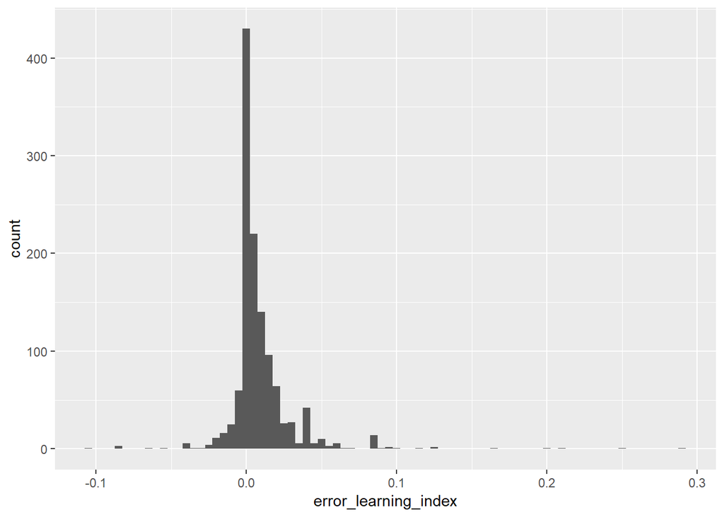

```r
ggplot(error_rates, aes(error_learning_index)) +
  geom_histogram(binwidth = 0.005)
```

```r
error_rates_long <- error_rates %>%
  gather(., "type", "error_rate", error_rate_filler_NoGo:error_rate_unh_NoGo)
```

The mean of the error learning index is 0.0090654 with a standard deviation of 0.0231942, so for most people, this index is extremely close to zero. I suppose this is mainly due to the fact that error rates are very low in general with an overall mean error rate of 0.0108742 (sd = 0.0220378).

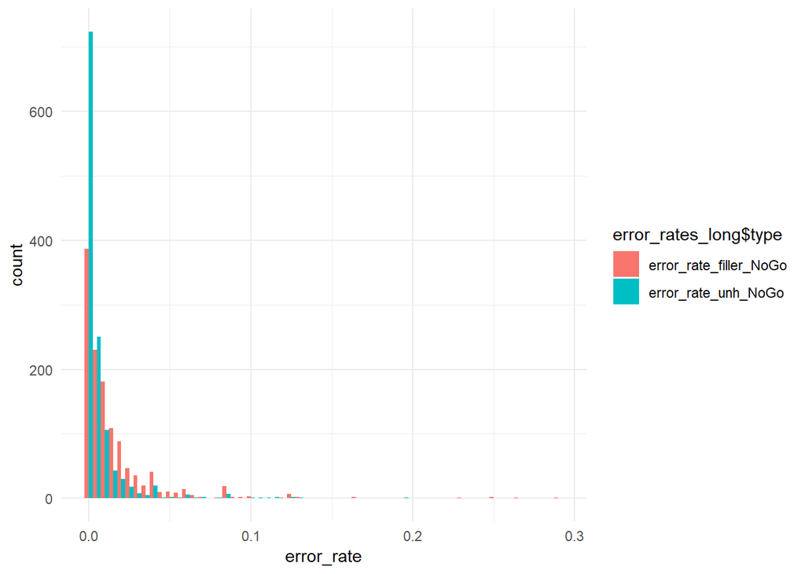

```r
ggplot(error_rates_long, aes(error_rate, fill = error_rates_long$type)) +
  geom_histogram(position = "dodge", binwidth = .005) +
  theme_minimal()
```

Nevertheless, we can run the regression including the error learning index as a predictor.

```r
errors_FFQ <- full_join(error_rates, FFQ_full, by = "email_id")
errors_FFQ_long <- errors_FFQ %>%
  gather(., "timepoint", "food_intake", c("unhlthymean", "unhlthymean1")) %>%
  dplyr::mutate(timepoint = recode(timepoint,
                                   "unhlthymean" = "T1",
                                   "unhlthymean1" = "T2"))

error_index_model_no_cov <- lme4::lmer(food_intake ~ error_learning_index*timepoint + (1|email_id), data = errors_FFQ_long)

error_index_model <- lme4::lmer(food_intake ~ error_learning_index*timepoint +
                                   bmi0 + age + as.factor(gender) + as.factor(smoker0) + as.factor(diet0) +
                                  (1|email_id), data = errors_FFQ_long)

stargazer::stargazer(error_index_model_no_cov, error_index_model,
                     type = "html")
```

|  | *Dependent variable:* |  |
| --- | --- | --- |
|  | food_intake |  |
|  | (1) | (2) |
| error_learning_index | -0.752 | -1.925 |
|  | (1.241) | (1.375) |
| timepointT2 | -0.363*** | -0.365*** |
|  | (0.029) | (0.033) |
| bmi0 |  | 0.020*** |
|  |  | (0.005) |
| age |  | -0.013*** |
|  |  | (0.002) |
| as.factor(gender)Male |  | 0.065 |
|  |  | (0.065) |
| as.factor(smoker0)Yes |  | 0.056 |
|  |  | (0.112) |
| as.factor(diet0)Yes |  | -0.191*** |
|  |  | (0.059) |
| error_learning_index:timepointT2 | 0.811 | 1.334 |
|  | (1.201) | (1.335) |
| Constant | 3.267*** | 3.329*** |
|  | (0.031) | (0.154) |
| Observations | 2,426 | 1,771 |
| Log Likelihood | -3,243.001 | -2,332.955 |
| Akaike Inf. Crit. | 6,498.001 | 4,687.909 |
| Bayesian Inf. Crit. | 6,532.765 | 4,748.182 |
| *Note:* | p<0.1; p<0.05; p<0.01 |  |

We see no significant effects of the error learning index on food intake in this mixed model. Again, this is probably due to the little variation we have in this variable.

# 3 Hypothesis 2: Differences between foods

## 3.1 Univariate regressions by food type

We now proceed to look at the regression models from Hypothesis 1.1 separately by food type, so we use the amount of trials for that specific food as a predictor and intake of that food as the outcome. Again, the interaction term is really what we’re interested in.

```r
long_by_food <- FoodT %>%
  gather(., "food_timepoint", "intake", c("crisp":"crispbr", "crisp1":"crispbr1")) %>%
  dplyr::mutate(food_timepoint = recode(food_timepoint,
                                   "alco" = "alco0",
                                   "bis" = "bis0",
                                   "bread" = "bread0",
                                   "cake" = "cake0",
                                   "cheese" = "cheese0",
                                   "chips" = "chips0",
                                   "choco" = "choco0",
                                   "crisp" = "crisp0",
                                   "crispbr" = "crispbr0",
                                   "ffood" = "ffood0",
                                   "fruit" = "fruit0",
                                   "fzdrink" = "fzdrink0",
                                   "ice" = "ice0",
                                   "meat" = "meat0",
                                   "pastri" = "pastri0",
                                   "pizza" = "pizza0",
                                   "sweet" = "sweet0",
                                   "vege" = "vege0")) %>%
  separate(., "food_timepoint", sep = -1, into = c("food", "time"))

# alcohol
alcohol <- lme4::lmer(intake ~ n_alcohol*time +
                        bmi01 + age + as.factor(gender) + as.factor(smoker0) + as.factor(diet0) + as.factor(metcon0) + (1|email_id), data = subset(long_by_food, food == "alco"))

# biscuits
biscuits <- lme4::lmer(intake ~ n_biscuits*time +
                         bmi01 + age + as.factor(gender) + as.factor(smoker0) + as.factor(diet0) + as.factor(metcon0) + (1|email_id), data = subset(long_by_food, food == "bis"))

# bread
bread <- lme4::lmer(intake ~ n_bread*time +
                      bmi01 + age + as.factor(gender) + as.factor(smoker0) + as.factor(diet0) + as.factor(metcon0)  + (1|email_id), data = subset(long_by_food, food == "bread"))

# cake
cake <- lme4::lmer(intake ~ n_cakes*time +
                     bmi01 + age + as.factor(gender) + as.factor(smoker0) + as.factor(diet0) + as.factor(metcon0)  + (1|email_id), data = subset(long_by_food, food == "cake"))

# cheese
cheese <- lme4::lmer(intake ~ n_cheese*time +
                       bmi01 + age + as.factor(gender) + as.factor(smoker0) + as.factor(diet0) + as.factor(metcon0)  + (1|email_id), data = subset(long_by_food, food == "cheese"))

# chips ######### This doesn't work as there's no data on chips!!

# chocolate
chocolate <- lme4::lmer(intake ~ n_chocolate*time +
                          bmi01 + age + as.factor(gender) + as.factor(smoker0) + as.factor(diet0) + as.factor(metcon0)  + (1|email_id), data = subset(long_by_food, food == "choco"))

# crisps
crisps <- lme4::lmer(intake ~ n_crisps*time +
                         bmi01 + age + as.factor(gender) + as.factor(smoker0) + as.factor(diet0) + as.factor(metcon0)  + (1|email_id), data = subset(long_by_food, food == "crisp"))


# crispbread
# crispbread <- lme4::lmer(intake ~ n_crisps*time +
#                           bmi01 + age + as.factor(gender) + as.factor(smoker0) + as.factor(diet0) + as.factor(metcon0)  + (1|email_id), data = subset(long_by_food, food == "crispbr"))
#summary(lmerTest::lmer(intake ~ n_crisps*time +
#                         bmi01 + age + as.factor(gender) + as.factor(smoker0) + as.factor(diet0) + as.factor(metcon0)  + (1|email_id), data = subset(long_by_food, food == "crispbr")))

# fast food
fastfood <- lme4::lmer(intake ~ n_fastfood*time +
                         bmi01 + age + as.factor(gender) + as.factor(smoker0) + as.factor(diet0) + as.factor(metcon0)  + (1|email_id), data = subset(long_by_food, food == "ffood"))

# fruit
fruit <- lme4::lmer(intake ~ n_fruit*time +
                      bmi01 + age + as.factor(gender) + as.factor(smoker0) + as.factor(diet0) + as.factor(metcon0)  + (1|email_id), data = subset(long_by_food, food == "fruit"))

# fizzy drinks
fizzydrinks <- lme4::lmer(intake ~ n_fizzydrinks*time +
                            bmi01 + age + as.factor(gender) + as.factor(smoker0) + as.factor(diet0) + as.factor(metcon0)  + (1|email_id), data = subset(long_by_food, food == "fzdrink"))

# ice cream ######### This doesn't work as there's no data on ice cream!!

# meat
meat <- lme4::lmer(intake ~ n_meat*time +
                     bmi01 + age + as.factor(gender) + as.factor(smoker0) + as.factor(diet0) + as.factor(metcon0)  + (1|email_id), data = subset(long_by_food, food == "meat"))

# pastries ######### This doesn't work as there's no data on pastries!!

# pizza
pizza <- lme4::lmer(intake ~ n_pizza*time +
                      bmi01 + age + as.factor(gender) + as.factor(smoker0) + as.factor(diet0) + as.factor(metcon0)  + (1|email_id), data = subset(long_by_food, food == "pizza"))

# sweets
sweets <- lme4::lmer(intake ~ n_sweets*time +
                       bmi01 + age + as.factor(gender) + as.factor(smoker0) + as.factor(diet0) + as.factor(metcon0)  + (1|email_id), data = subset(long_by_food, food == "sweet"))

# vege
vege <- lme4::lmer(intake ~ n_vegetables*time +
                     bmi01 + age + as.factor(gender) + as.factor(smoker0) + as.factor(diet0) + as.factor(metcon0)  + (1|email_id), data = subset(long_by_food, food == "vege"))

stargazer::stargazer(alcohol, biscuits, bread, cake, cheese, chocolate, crisps, fastfood, fruit, fizzydrinks, meat, pizza, sweets, vege,
                     type = "html")
```

|  | *Dependent variable:* |  |  |  |  |  |  |  |  |  |  |  |  |  |
| --- | --- | --- | --- | --- | --- | --- | --- | --- | --- | --- | --- | --- | --- | --- |
|  | intake |  |  |  |  |  |  |  |  |  |  |  |  |  |
|  | (1) | (2) | (3) | (4) | (5) | (6) | (7) | (8) | (9) | (10) | (11) | (12) | (13) | (14) |
| n_alcohol | 0.015*** |  |  |  |  |  |  |  |  |  |  |  |  |  |
|  | (0.002) |  |  |  |  |  |  |  |  |  |  |  |  |  |
| n_biscuits |  | 0.003*** |  |  |  |  |  |  |  |  |  |  |  |  |
|  |  | (0.001) |  |  |  |  |  |  |  |  |  |  |  |  |
| n_bread |  |  | 0.003* |  |  |  |  |  |  |  |  |  |  |  |
|  |  |  | (0.002) |  |  |  |  |  |  |  |  |  |  |  |
| n_cakes |  |  |  | 0.003** |  |  |  |  |  |  |  |  |  |  |
|  |  |  |  | (0.001) |  |  |  |  |  |  |  |  |  |  |
| n_cheese |  |  |  |  | 0.0002 |  |  |  |  |  |  |  |  |  |
|  |  |  |  |  | (0.002) |  |  |  |  |  |  |  |  |  |
| n_chocolate |  |  |  |  |  | 0.004*** |  |  |  |  |  |  |  |  |
|  |  |  |  |  |  | (0.001) |  |  |  |  |  |  |  |  |
| n_crisps |  |  |  |  |  |  | 0.002* |  |  |  |  |  |  |  |
|  |  |  |  |  |  |  | (0.001) |  |  |  |  |  |  |  |
| n_fastfood |  |  |  |  |  |  |  | 0.002* |  |  |  |  |  |  |
|  |  |  |  |  |  |  |  | (0.001) |  |  |  |  |  |  |
| n_fruit |  |  |  |  |  |  |  |  | 0.001 |  |  |  |  |  |
|  |  |  |  |  |  |  |  |  | (0.001) |  |  |  |  |  |
| n_fizzydrinks |  |  |  |  |  |  |  |  |  | 0.025*** |  |  |  |  |
|  |  |  |  |  |  |  |  |  |  | (0.004) |  |  |  |  |
| n_meat |  |  |  |  |  |  |  |  |  |  | 0.0001 |  |  |  |
|  |  |  |  |  |  |  |  |  |  |  | (0.003) |  |  |  |
| n_pizza |  |  |  |  |  |  |  |  |  |  |  | 0.008*** |  |  |
|  |  |  |  |  |  |  |  |  |  |  |  | (0.003) |  |  |
| n_sweets |  |  |  |  |  |  |  |  |  |  |  |  | 0.012*** |  |
|  |  |  |  |  |  |  |  |  |  |  |  |  | (0.003) |  |
| n_vegetables |  |  |  |  |  |  |  |  |  |  |  |  |  | 0.001** |
|  |  |  |  |  |  |  |  |  |  |  |  |  |  | (0.0004) |
| time1 | -0.100** | -0.287*** | -0.403*** | -0.292*** | -0.412*** | -0.359*** | 0.050 | -0.193*** | 0.193*** | -0.230*** | -0.181*** | -0.106*** | -0.599*** | 0.086 |
|  | (0.044) | (0.074) | (0.056) | (0.068) | (0.056) | (0.080) | (0.107) | (0.041) | (0.064) | (0.050) | (0.043) | (0.034) | (0.065) | (0.057) |
| bmi01 | -0.026*** | -0.001 | 0.032*** | 0.014* | 0.033*** | -0.003 | 0.036*** | 0.038*** | -0.032*** | 0.042*** | 0.036*** | 0.010** | 0.019** | -0.030*** |
|  | (0.008) | (0.009) | (0.009) | (0.008) | (0.009) | (0.009) | (0.012) | (0.006) | (0.009) | (0.009) | (0.009) | (0.005) | (0.010) | (0.008) |
| age | 0.012*** | -0.007* | -0.010** | -0.010*** | -0.009** | -0.011*** | -0.014*** | -0.034*** | 0.021*** | -0.026*** | -0.012*** | -0.017*** | 0.002 | 0.018*** |
|  | (0.004) | (0.004) | (0.004) | (0.003) | (0.004) | (0.004) | (0.005) | (0.003) | (0.004) | (0.004) | (0.004) | (0.002) | (0.004) | (0.004) |
| as.factor(gender)Male | 0.081 | -0.136 | 0.148 | -0.006 | 0.137 | -0.256** | -0.115 | 0.281*** | -0.505*** | 0.410*** | 0.373*** | 0.244*** | 0.013 | -0.598*** |
|  | (0.111) | (0.113) | (0.121) | (0.100) | (0.121) | (0.120) | (0.146) | (0.081) | (0.114) | (0.121) | (0.118) | (0.063) | (0.130) | (0.102) |
| as.factor(smoker0)Yes | 1.019*** | 0.139 | 0.249 | 0.005 | 0.276 | -0.262 | 0.423* | -0.041 | -0.635*** | 0.573*** | -0.176 | 0.052 | -0.105 | -0.322* |
|  | (0.189) | (0.193) | (0.207) | (0.171) | (0.208) | (0.205) | (0.233) | (0.138) | (0.196) | (0.206) | (0.203) | (0.107) | (0.223) | (0.174) |
| as.factor(diet0)Yes | -0.127 | -0.139 | -0.533*** | -0.183** | -0.513*** | -0.146 | -0.247* | -0.160** | 0.386*** | 0.011 | -0.076 | -0.164*** | -0.315*** | 0.256*** |
|  | (0.101) | (0.102) | (0.109) | (0.090) | (0.110) | (0.108) | (0.136) | (0.073) | (0.103) | (0.110) | (0.107) | (0.057) | (0.118) | (0.092) |
| as.factor(metcon0)Yes | -0.178 | -0.178 | 0.044 | -0.076 | 0.039 | -0.131 | 0.525*** | 0.200* | 0.007 | 0.374** | -0.122 | 0.012 | 0.128 | 0.003 |
|  | (0.159) | (0.159) | (0.168) | (0.140) | (0.169) | (0.166) | (0.198) | (0.113) | (0.159) | (0.171) | (0.165) | (0.088) | (0.182) | (0.141) |
| n_alcohol:time1 | -0.003** |  |  |  |  |  |  |  |  |  |  |  |  |  |
|  | (0.001) |  |  |  |  |  |  |  |  |  |  |  |  |  |
| n_biscuits:time1 |  | -0.003*** |  |  |  |  |  |  |  |  |  |  |  |  |
|  |  | (0.001) |  |  |  |  |  |  |  |  |  |  |  |  |
| n_bread:time1 |  |  | -0.003** |  |  |  |  |  |  |  |  |  |  |  |
|  |  |  | (0.001) |  |  |  |  |  |  |  |  |  |  |  |
| n_cakes:time1 |  |  |  | -0.002 |  |  |  |  |  |  |  |  |  |  |
|  |  |  |  | (0.001) |  |  |  |  |  |  |  |  |  |  |
| n_cheese:time1 |  |  |  |  | -0.004** |  |  |  |  |  |  |  |  |  |
|  |  |  |  |  | (0.002) |  |  |  |  |  |  |  |  |  |
| n_chocolate:time1 |  |  |  |  |  | -0.003*** |  |  |  |  |  |  |  |  |
|  |  |  |  |  |  | (0.001) |  |  |  |  |  |  |  |  |
| n_crisps:time1 |  |  |  |  |  |  | -0.002** |  |  |  |  |  |  |  |
|  |  |  |  |  |  |  | (0.001) |  |  |  |  |  |  |  |
| n_fastfood:time1 |  |  |  |  |  |  |  | -0.003** |  |  |  |  |  |  |
|  |  |  |  |  |  |  |  | (0.001) |  |  |  |  |  |  |
| n_fruit:time1 |  |  |  |  |  |  |  |  | 0.001 |  |  |  |  |  |
|  |  |  |  |  |  |  |  |  | (0.0005) |  |  |  |  |  |
| n_fizzydrinks:time1 |  |  |  |  |  |  |  |  |  | -0.005* |  |  |  |  |
|  |  |  |  |  |  |  |  |  |  | (0.003) |  |  |  |  |
| n_meat:time1 |  |  |  |  |  |  |  |  |  |  | -0.002 |  |  |  |
|  |  |  |  |  |  |  |  |  |  |  | (0.002) |  |  |  |
| n_pizza:time1 |  |  |  |  |  |  |  |  |  |  |  | -0.010*** |  |  |
|  |  |  |  |  |  |  |  |  |  |  |  | (0.003) |  |  |
| n_sweets:time1 |  |  |  |  |  |  |  |  |  |  |  |  | -0.005 |  |
|  |  |  |  |  |  |  |  |  |  |  |  |  | (0.003) |  |
| n_vegetables:time1 |  |  |  |  |  |  |  |  |  |  |  |  |  | 0.001*** |
|  |  |  |  |  |  |  |  |  |  |  |  |  |  | (0.0003) |
| Constant | 2.758*** | 3.541*** | 4.696*** | 3.111*** | 4.637*** | 4.611*** | 2.080*** | 2.669*** | 5.159*** | 2.093*** | 4.124*** | 2.424*** | 3.141*** | 5.622*** |
|  | (0.264) | (0.269) | (0.287) | (0.238) | (0.288) | (0.285) | (0.365) | (0.192) | (0.272) | (0.287) | (0.281) | (0.149) | (0.310) | (0.241) |
| Observations | 1,709 | 1,725 | 1,760 | 1,737 | 1,751 | 1,749 | 691 | 1,721 | 1,759 | 1,705 | 1,753 | 1,704 | 1,740 | 1,760 |
| Log Likelihood | -2,962.380 | -3,287.947 | -3,355.859 | -3,154.335 | -3,349.770 | -3,401.085 | -1,193.871 | -2,650.096 | -3,141.926 | -3,154.637 | -3,128.600 | -2,268.370 | -3,504.528 | -2,946.441 |
| Akaike Inf. Crit. | 5,948.760 | 6,599.895 | 6,735.718 | 6,332.671 | 6,723.540 | 6,826.171 | 2,411.741 | 5,324.191 | 6,307.851 | 6,333.273 | 6,281.201 | 4,560.740 | 7,033.056 | 5,916.883 |
| Bayesian Inf. Crit. | 6,014.084 | 6,665.331 | 6,801.395 | 6,398.190 | 6,789.156 | 6,891.772 | 2,466.199 | 5,389.599 | 6,373.521 | 6,398.569 | 6,346.830 | 4,626.028 | 7,098.595 | 5,982.560 |
| *Note:* | p<0.1; p<0.05; p<0.01 |  |  |  |  |  |  |  |  |  |  |  |  |  |

## 3.2 Multivariate regression

In hypothesis 2 we pre-registered running a multivariate model. The model predicts food intake at T2 for the different foods with food intake at T1 and the amounts of trials of the different foods as predictors. The same covariates as earlier are included in the model. Obviously, this is hard to interpret but it seems like no consistent pattern is emerging - there do not seem to be clear “cross-over” effects from one kind of food to others. I am leaving out these results as it takes lots of space and is a drag to look at.

```r
#### Let's go for the multivariate model #### Hypothesis 2
multivar <- lm(cbind(crisp1, choco1, bis1,
                      sweet1, cake1, alco1,
                     bread1, cheese1, ffood1,
                     fzdrink1, meat1, pizza1,
                     fruit1, vege1, crispbr1) ~
                             n_alcohol + n_biscuits + n_bread +
                             n_cakes + n_cheese + n_chocolate +
                             n_crisps + n_fastfood + n_fizzydrinks +
                             n_icecream + n_meat + n_pastries +
                             n_pizza + n_sweets +
                 + crisp + choco + bis +
               sweet + cake + alco +
               bread + cheese + ffood +
               fzdrink + meat + pizza +
               fruit + vege + crispbr +
                 bmi0 + age + as.factor(gender) + as.factor(smoker0) + as.factor(diet0),
                           data = FoodT)
summary(multivar)
```

# 4 Hypothesis 3: Healthy foods

## 4.1 Overall healthy foods

We first do the same thing as for the unhealthy foods: we run a random-intercept mixed model with the number of trials as the main predictor of interest, with and without control variables.

```r
FoodT_long_healthy <- FoodT %>%
  dplyr::select(., metcon0, email_id, bmi0, age, gender, smoker0, diet0, n_healthy, hlthymean, hlthymean1) %>%
  gather(., "timepoint", "healthy_intake", c("hlthymean", "hlthymean1")) %>%
  dplyr::mutate(timepoint = recode_factor(timepoint,
                                          "hlthymean" = "T1",
                                          "hlthymean1" = "T2"))


mixed_model_FFQ_T2_healthy_no_cov <- lme4::lmer(healthy_intake ~ n_healthy*timepoint +
                                   (1|email_id),
                                 data = FoodT_long_healthy,
                                 na.action = na.exclude)
mixed_model_FFQ_T2_healthy <- lme4::lmer(healthy_intake ~ n_healthy*timepoint +
                                   bmi0 + age + as.factor(gender) + as.factor(smoker0) + as.factor(diet0) + as.factor(metcon0) +
                                   (1|email_id),
                                 data = FoodT_long_healthy,
                                 na.action = na.exclude)
stargazer::stargazer(mixed_model_FFQ_T2_healthy_no_cov, mixed_model_FFQ_T2_healthy,
                     type = "html")
```

|  | *Dependent variable:* |  |
| --- | --- | --- |
|  | healthy_intake |  |
|  | (1) | (2) |
| n_healthy | 0.001*** | 0.0003 |
|  | (0.0002) | (0.0002) |
| timepointT2 | 0.150*** | 0.141*** |
|  | (0.048) | (0.052) |
| bmi0 |  | -0.031*** |
|  |  | (0.007) |
| age |  | 0.020*** |
|  |  | (0.003) |
| as.factor(gender)Male |  | -0.553*** |
|  |  | (0.097) |
| as.factor(smoker0)Yes |  | -0.480*** |
|  |  | (0.167) |
| as.factor(diet0)Yes |  | 0.323*** |
|  |  | (0.088) |
| as.factor(metcon0)Yes |  | 0.002 |
|  |  | (0.135) |
| n_healthy:timepointT2 | 0.0002* | 0.0003** |
|  | (0.0001) | (0.0001) |
| Constant | 5.179*** | 5.378*** |
|  | (0.061) | (0.231) |
| Observations | 2,468 | 2,468 |
| Log Likelihood | -4,001.542 | -2,830.375 |
| Akaike Inf. Crit. | 8,015.084 | 5,684.750 |
| Bayesian Inf. Crit. | 8,049.828 | 5,750.441 |
| *Note:* | p<0.1; p<0.05; p<0.01 |  |

## 4.2 RT learning index

```r
FoodT_by_trial_RT <- FoodT_training %>%
  dplyr::select(., "login", "date", tidyselect::contains("_rt"), -"mean_rt") %>%
  gather(., key = "trial", value = "RT", tidyselect::contains("_rt"))
FoodT_by_trial_RT$trial <- gsub(pattern = "_rt", replacement = "", FoodT_by_trial_RT$trial, fixed = TRUE)

FoodT_by_trial_types <- FoodT_training %>%
  dplyr::select(., "login", contains("_type")) %>%
  gather(., key = "trial", value = "type", tidyselect::contains("_type"))
FoodT_by_trial_types$trial <- as.factor(gsub(pattern = "_type", replacement = "", FoodT_by_trial_RT$trial, fixed = TRUE))

FoodT_by_trial_correct <- FoodT_training %>%
  dplyr::select(., "login", contains("_correct")) %>%
  gather(., key = "trial", value = "correct", tidyselect::contains("_correct"))
FoodT_by_trial_correct$trial <- gsub(pattern = "_correct", replacement = "", FoodT_by_trial_RT$trial, fixed = TRUE)

FoodT_by_trial_image <- FoodT_training %>%
  dplyr::select(., "login", contains("_image"))%>%
  gather(., key = "trial", value = "image", tidyselect::contains("_image"))
FoodT_by_trial_image$trial <- as.factor(gsub(pattern = "_image", replacement = "", FoodT_by_trial_RT$trial, fixed = TRUE))

FoodT_RT <- dplyr::bind_cols(list(FoodT_by_trial_RT, FoodT_by_trial_types, FoodT_by_trial_correct, FoodT_by_trial_image)) %>%
  dplyr::select(., -c(trial1, trial2, trial3, login1, login2, login3)) %>%
  dplyr::mutate(type = recode(type,
                              "control-no-go" = "control_no_go",
                              "control-go" = "control_go",
                              "go" = "go",
                              "no-go" = "no_go")) %>%
  rename(., "email_id" = "login") %>%
  subset(., type == "go"|type == "control_go") %>%
  subset(., RT > 0 & RT < 1500) # Now this dataframe FoodT_RT has only Go-trials


mean_RTs_by_type <- FoodT_RT %>%
  group_by(email_id, type) %>%
  summarise("ind_mean_RT" = mean(RT)) %>%
  spread("type", "ind_mean_RT") %>%
  mutate(., RT_learning_index = control_go - go) # So here we have our RT learning index: if it's positive, that participant took longer to respond to control stimuli (as we would expect)
```

Lastly, we want to investigate how reaction time differences between healthy Go-trials and control Go-trials differ, again following the logic that the 100% reliable mapping speeds up reactions to healthy foods. To compare the mean RTs for healthy foods and control images, we run a paired t-test:

```r
t.test(mean_RTs_by_type$control_go, mean_RTs_by_type$go,
       paired = TRUE)
```

```
##
##  Paired t-test
##
## data:  mean_RTs_by_type$control_go and mean_RTs_by_type$go
## t = 30.024, df = 1233, p-value < 0.00000000000000022
## alternative hypothesis: true difference in means is not equal to 0
## 95 percent confidence interval:
##  15.86952 18.08845
## sample estimates:
## mean of the differences
##                16.97898
```

The mean reaction times are 745.77, sd = 86.5 for healthy foods and 762.75, sd = 87.57 for fillers.

The *RT learning index* is a participant’s difference between mean reaction time to healthy Go-trials and control Go-trials. Here is the distribution of the reaction times and the index. The mean of the index is 16.98 with sd = 19.87.

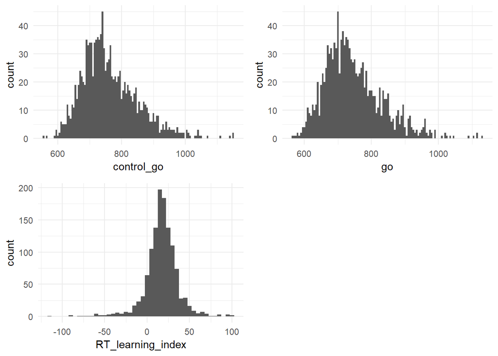

```r
p1 <- ggplot(mean_RTs_by_type, aes(control_go)) +
  geom_histogram(binwidth = 5) +
  theme_minimal()

p2 <- ggplot(mean_RTs_by_type, aes(go)) +
  geom_histogram(binwidth = 5) +
  theme_minimal()

p3 <- ggplot(mean_RTs_by_type, aes(RT_learning_index)) +
  geom_histogram(binwidth = 5) +
  theme_minimal()

cowplot::plot_grid(p1, p2, p3)
```

And now let’s run the regression model. Same procedure as earlier.

```r
RTs_FFQ <- full_join(mean_RTs_by_type, FFQ_full, by = "email_id")
RTs_FFQ_long <- RTs_FFQ %>%
  gather(., "timepoint", "healthy_intake", c("hlthymean", "hlthymean1")) %>%
  dplyr::mutate(timepoint = recode(timepoint,
                                   "hlthymean" = "T1",
                                   "hlthymean1" = "T2"))

# And here is the model with the RT learning index, first without then with covariates
RT_learning_no_cov <- lme4::lmer(healthy_intake ~ RT_learning_index*timepoint + (1|email_id), data = RTs_FFQ_long)
RT_learning <- lme4::lmer(healthy_intake ~ RT_learning_index*timepoint +
                                 bmi0 + age + as.factor(gender) + as.factor(smoker0) + as.factor(diet0) + as.factor(metcon0) +
                                (1|email_id), data = RTs_FFQ_long)

stargazer::stargazer(RT_learning_no_cov, RT_learning,
                     type = "html")
```

|  | *Dependent variable:* |  |
| --- | --- | --- |
|  | healthy_intake |  |
|  | (1) | (2) |
| RT_learning_index | 0.001 | 0.001 |
|  | (0.002) | (0.002) |
| timepointT2 | 0.230*** | 0.250*** |
|  | (0.044) | (0.048) |
| bmi0 |  | -0.030*** |
|  |  | (0.007) |
| age |  | 0.022*** |
|  |  | (0.003) |
| as.factor(gender)Male |  | -0.573*** |
|  |  | (0.098) |
| as.factor(smoker0)Yes |  | -0.492*** |
|  |  | (0.168) |
| as.factor(diet0)Yes |  | 0.331*** |
|  |  | (0.088) |
| as.factor(metcon0)Yes |  | 0.013 |
|  |  | (0.136) |
| RT_learning_index:timepointT2 | -0.001 | -0.002 |
|  | (0.002) | (0.002) |
| Constant | 5.288*** | 5.355*** |
|  | (0.056) | (0.233) |
| Observations | 2,418 | 1,762 |
| Log Likelihood | -4,005.471 | -2,830.787 |
| Akaike Inf. Crit. | 8,022.941 | 5,685.574 |
| Bayesian Inf. Crit. | 8,057.685 | 5,751.265 |
| *Note:* | p<0.1; p<0.05; p<0.01 |  |